# examples_0330

A quadratic polynomial, $f(x)$, is generated by randomly selecting two parameters, $B$ and $C$, in the equation below.

$$f(x)~=~x^2+Bx+C$$

Notice the leading coefficient (of the quadratic term) is 1. However the linear coefficient and the constant are randomly determined.

When $y=f(x)$ is graphed below, you notice it has zeros (roots, $x$-intercepts) at coordinates $(-6,0)$ and $(-2,0)$.

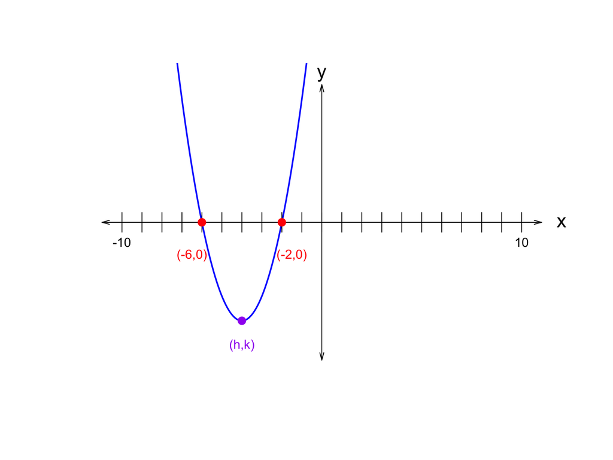

### Factored form

The polynomial $f(x)$ can be expressed in **factored form**. Which option correctly expresses $f(x)$ in factored form?

1. $f(x) = (x-{6})\cdot (x-{2})$
2. $f(x) = (x+{6})\cdot (x+{2})$
3. $f(x) = (x+{6})\cdot (x-{2})$
4. $f(x) = (x-{6})\cdot (x+{2})$

### Standard (expanded) form

The polynomial $f(x)$ can be expressed in **standard form**. Which option correctly expresses $f(x)$ in standard form?

7. $f(x) = x^{2}+{4}x-{12}$
8. $f(x) = x^{2}+{8}x+{12}$
9. $f(x) = x^{2}-{4}x-{12}$
10. $f(x) = x^{2}-{8}x+{12}$

### Vertex form

The polynomial $f(x)$ can be expressed in **vertex form**:

$$f(x)~=~ (x-h)^2+k$$

where coordinates $(h,k)$ are at the vertex of the parabola (as marked on the graph). Which option correctly expresses $f(x)$ in vertex form?

16. $f(x)~=~(x-4)^2-4$
17. $f(x)~=~(x-2)^2-16$
18. $f(x)~=~(x+2)^2-16$
19. $f(x)~=~(x+4)^2-4$

If the zeros are at $(p,0)$ and $(q,0)$, then the factored form will be: $f(x)~=~(x-p)\cdot(x-q)$. In our case, $p=-6$ and $q=-2$, so in factored form:

$$f(x) = (x+{6})\cdot (x+{2})$$

To get the standard (expanded) form, we can multiply the two linear binomials (using the [FOIL method](https://en.wikipedia.org/wiki/FOIL_method) or box method).

| * | $x$ | $6$ |
| --- | --- | --- |
| $x$ | $x^2$ | ${6}x$ |
| $2$ | ${2}x$ | $12$ |

$$f(x)~=~x^{2}+{2}x+{6}x+{12}$$

Combine like terms.

$$f(x)~=~x^{2}+{8}x+{12}$$

To get the vertex form, first average $p$ and $q$ to get $h$.

$$h~=~ \frac{{-6}-{2}}{2} ~=~
-4$$

Then, plug $x=-4$ into the factored form or the standard form to get $k$.

$$k~=~({-4}+{6})\cdot({-4}+{2}) ~=~
-4$$
$$k~=~(-4)^2+(8)(-4)+(12) ~=~
-4$$

So,

$$f(x)~=~(x+4)^2-4$$

A quadratic polynomial, $f(x)$, is generated by randomly selecting two parameters, $B$ and $C$, in the equation below.

$$f(x)~=~x^2+Bx+C$$

Notice the leading coefficient (of the quadratic term) is 1. However the linear coefficient and the constant are randomly determined.

When $y=f(x)$ is graphed below, you notice it has zeros (roots, $x$-intercepts) at coordinates $(-1,0)$ and $(3,0)$.

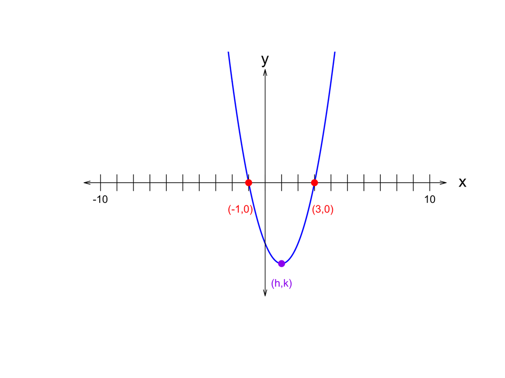

### Factored form

The polynomial $f(x)$ can be expressed in **factored form**. Which option correctly expresses $f(x)$ in factored form?

1. $f(x) = (x+{1})\cdot (x-{3})$
2. $f(x) = (x-{1})\cdot (x-{3})$
3. $f(x) = (x+{1})\cdot (x+{3})$
4. $f(x) = (x-{1})\cdot (x+{3})$

### Standard (expanded) form

The polynomial $f(x)$ can be expressed in **standard form**. Which option correctly expresses $f(x)$ in standard form?

7. $f(x) = x^{2}+{4}x+{3}$
8. $f(x) = x^{2}-{4}x+{3}$
9. $f(x) = x^{2}-{2}x-{3}$
10. $f(x) = x^{2}+{2}x-{3}$

### Vertex form

The polynomial $f(x)$ can be expressed in **vertex form**:

$$f(x)~=~ (x-h)^2+k$$

where coordinates $(h,k)$ are at the vertex of the parabola (as marked on the graph). Which option correctly expresses $f(x)$ in vertex form?

16. $f(x)~=~(x+2)^2-1$
17. $f(x)~=~(x-1)^2-4$
18. $f(x)~=~(x+1)^2-4$
19. $f(x)~=~(x-2)^2-1$

If the zeros are at $(p,0)$ and $(q,0)$, then the factored form will be: $f(x)~=~(x-p)\cdot(x-q)$. In our case, $p=-1$ and $q=3$, so in factored form:

$$f(x) = (x+{1})\cdot (x-{3})$$

To get the standard (expanded) form, we can multiply the two linear binomials (using the [FOIL method](https://en.wikipedia.org/wiki/FOIL_method) or box method).

| * | $x$ | $1$ |
| --- | --- | --- |
| $x$ | $x^2$ | $x$ |
| $-3$ | ${-3}x$ | $-3$ |

$$f(x)~=~x^{2}-{3}x+x-{3}$$

Combine like terms.

$$f(x)~=~x^{2}-{2}x-{3}$$

To get the vertex form, first average $p$ and $q$ to get $h$.

$$h~=~ \frac{{-1}+{3}}{2} ~=~
1$$

Then, plug $x=1$ into the factored form or the standard form to get $k$.

$$k~=~({1}+{1})\cdot({1}-{3}) ~=~
-4$$
$$k~=~(1)^2+(-2)(1)+(-3) ~=~
-4$$

So,

$$f(x)~=~(x-1)^2-4$$

A quadratic polynomial, $f(x)$, is generated by randomly selecting two parameters, $B$ and $C$, in the equation below.

$$f(x)~=~x^2+Bx+C$$

Notice the leading coefficient (of the quadratic term) is 1. However the linear coefficient and the constant are randomly determined.

When $y=f(x)$ is graphed below, you notice it has zeros (roots, $x$-intercepts) at coordinates $(-3,0)$ and $(5,0)$.

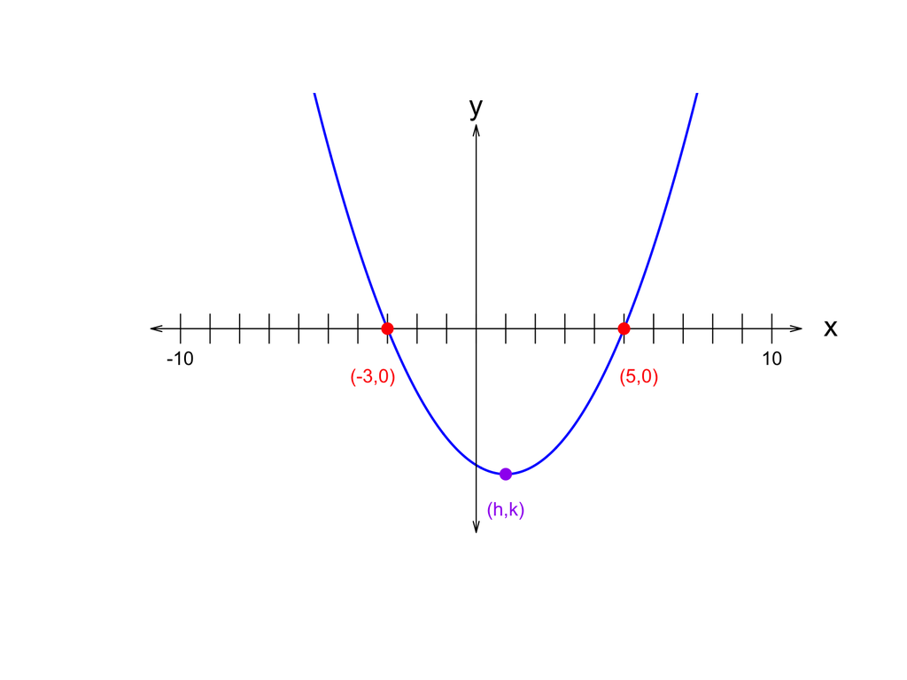

### Factored form

The polynomial $f(x)$ can be expressed in **factored form**. Which option correctly expresses $f(x)$ in factored form?

1. $f(x) = (x+{3})\cdot (x+{5})$
2. $f(x) = (x-{3})\cdot (x+{5})$
3. $f(x) = (x+{3})\cdot (x-{5})$
4. $f(x) = (x-{3})\cdot (x-{5})$

### Standard (expanded) form

The polynomial $f(x)$ can be expressed in **standard form**. Which option correctly expresses $f(x)$ in standard form?

7. $f(x) = x^{2}-{8}x+{15}$
8. $f(x) = x^{2}+{8}x+{15}$
9. $f(x) = x^{2}+{2}x-{15}$
10. $f(x) = x^{2}-{2}x-{15}$

### Vertex form

The polynomial $f(x)$ can be expressed in **vertex form**:

$$f(x)~=~ (x-h)^2+k$$

where coordinates $(h,k)$ are at the vertex of the parabola (as marked on the graph). Which option correctly expresses $f(x)$ in vertex form?

16. $f(x)~=~(x+4)^2-1$
17. $f(x)~=~(x-1)^2-16$
18. $f(x)~=~(x-4)^2-1$
19. $f(x)~=~(x+1)^2-16$

If the zeros are at $(p,0)$ and $(q,0)$, then the factored form will be: $f(x)~=~(x-p)\cdot(x-q)$. In our case, $p=-3$ and $q=5$, so in factored form:

$$f(x) = (x+{3})\cdot (x-{5})$$

To get the standard (expanded) form, we can multiply the two linear binomials (using the [FOIL method](https://en.wikipedia.org/wiki/FOIL_method) or box method).

| * | $x$ | $3$ |
| --- | --- | --- |
| $x$ | $x^2$ | ${3}x$ |
| $-5$ | ${-5}x$ | $-15$ |

$$f(x)~=~x^{2}-{5}x+{3}x-{15}$$

Combine like terms.

$$f(x)~=~x^{2}-{2}x-{15}$$

To get the vertex form, first average $p$ and $q$ to get $h$.

$$h~=~ \frac{{-3}+{5}}{2} ~=~
1$$

Then, plug $x=1$ into the factored form or the standard form to get $k$.

$$k~=~({1}+{3})\cdot({1}-{5}) ~=~
-16$$
$$k~=~(1)^2+(-2)(1)+(-15) ~=~
-16$$

So,

$$f(x)~=~(x-1)^2-16$$

A quadratic polynomial, $f(x)$, is generated by randomly selecting two parameters, $B$ and $C$, in the equation below.

$$f(x)~=~x^2+Bx+C$$

Notice the leading coefficient (of the quadratic term) is 1. However the linear coefficient and the constant are randomly determined.

When $y=f(x)$ is graphed below, you notice it has zeros (roots, $x$-intercepts) at coordinates $(3,0)$ and $(9,0)$.

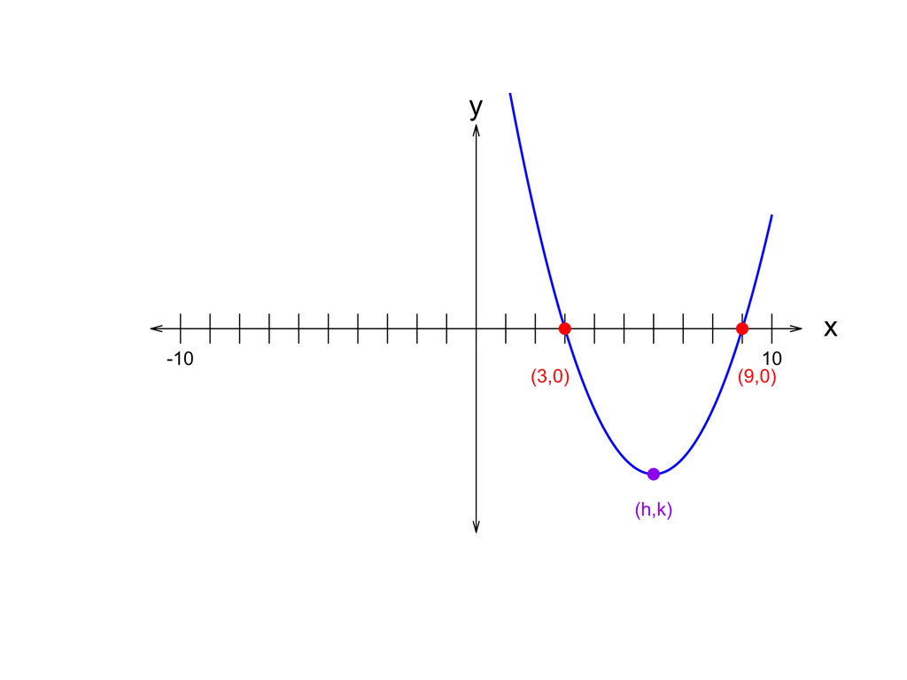

### Factored form

The polynomial $f(x)$ can be expressed in **factored form**. Which option correctly expresses $f(x)$ in factored form?

1. $f(x) = (x+{3})\cdot (x+{9})$
2. $f(x) = (x-{3})\cdot (x-{9})$
3. $f(x) = (x+{3})\cdot (x-{9})$
4. $f(x) = (x-{3})\cdot (x+{9})$

### Standard (expanded) form

The polynomial $f(x)$ can be expressed in **standard form**. Which option correctly expresses $f(x)$ in standard form?

7. $f(x) = x^{2}+{12}x+{27}$
8. $f(x) = x^{2}-{6}x-{27}$
9. $f(x) = x^{2}+{6}x-{27}$
10. $f(x) = x^{2}-{12}x+{27}$

### Vertex form

The polynomial $f(x)$ can be expressed in **vertex form**:

$$f(x)~=~ (x-h)^2+k$$

where coordinates $(h,k)$ are at the vertex of the parabola (as marked on the graph). Which option correctly expresses $f(x)$ in vertex form?

16. $f(x)~=~(x+3)^2-36$
17. $f(x)~=~(x+6)^2-9$
18. $f(x)~=~(x-6)^2-9$
19. $f(x)~=~(x-3)^2-36$

If the zeros are at $(p,0)$ and $(q,0)$, then the factored form will be: $f(x)~=~(x-p)\cdot(x-q)$. In our case, $p=3$ and $q=9$, so in factored form:

$$f(x) = (x-{3})\cdot (x-{9})$$

To get the standard (expanded) form, we can multiply the two linear binomials (using the [FOIL method](https://en.wikipedia.org/wiki/FOIL_method) or box method).

| * | $x$ | $-3$ |
| --- | --- | --- |
| $x$ | $x^2$ | ${-3}x$ |
| $-9$ | ${-9}x$ | $27$ |

$$f(x)~=~x^{2}-{9}x-{3}x+{27}$$

Combine like terms.

$$f(x)~=~x^{2}-{12}x+{27}$$

To get the vertex form, first average $p$ and $q$ to get $h$.

$$h~=~ \frac{{3}+{9}}{2} ~=~
6$$

Then, plug $x=6$ into the factored form or the standard form to get $k$.

$$k~=~({6}-{3})\cdot({6}-{9}) ~=~
-9$$
$$k~=~(6)^2+(-12)(6)+(27) ~=~
-9$$

So,

$$f(x)~=~(x-6)^2-9$$

A quadratic polynomial, $f(x)$, is generated by randomly selecting two parameters, $B$ and $C$, in the equation below.

$$f(x)~=~x^2+Bx+C$$

Notice the leading coefficient (of the quadratic term) is 1. However the linear coefficient and the constant are randomly determined.

When $y=f(x)$ is graphed below, you notice it has zeros (roots, $x$-intercepts) at coordinates $(-9,0)$ and $(-5,0)$.

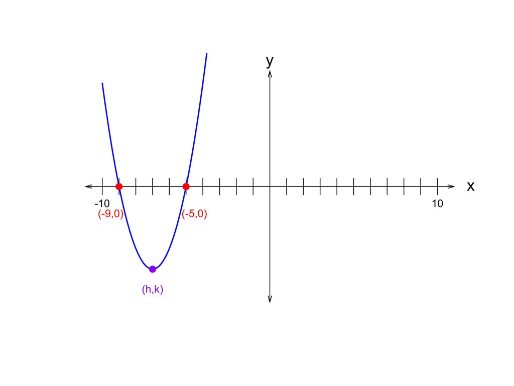

### Factored form

The polynomial $f(x)$ can be expressed in **factored form**. Which option correctly expresses $f(x)$ in factored form?

1. $f(x) = (x+{9})\cdot (x+{5})$
2. $f(x) = (x-{9})\cdot (x-{5})$
3. $f(x) = (x+{9})\cdot (x-{5})$
4. $f(x) = (x-{9})\cdot (x+{5})$

### Standard (expanded) form

The polynomial $f(x)$ can be expressed in **standard form**. Which option correctly expresses $f(x)$ in standard form?

7. $f(x) = x^{2}+{4}x-{45}$
8. $f(x) = x^{2}+{14}x+{45}$
9. $f(x) = x^{2}-{14}x+{45}$
10. $f(x) = x^{2}-{4}x-{45}$

### Vertex form

The polynomial $f(x)$ can be expressed in **vertex form**:

$$f(x)~=~ (x-h)^2+k$$

where coordinates $(h,k)$ are at the vertex of the parabola (as marked on the graph). Which option correctly expresses $f(x)$ in vertex form?

16. $f(x)~=~(x+7)^2-4$
17. $f(x)~=~(x-7)^2-4$
18. $f(x)~=~(x+2)^2-49$
19. $f(x)~=~(x-2)^2-49$

If the zeros are at $(p,0)$ and $(q,0)$, then the factored form will be: $f(x)~=~(x-p)\cdot(x-q)$. In our case, $p=-9$ and $q=-5$, so in factored form:

$$f(x) = (x+{9})\cdot (x+{5})$$

To get the standard (expanded) form, we can multiply the two linear binomials (using the [FOIL method](https://en.wikipedia.org/wiki/FOIL_method) or box method).

| * | $x$ | $9$ |
| --- | --- | --- |
| $x$ | $x^2$ | ${9}x$ |
| $5$ | ${5}x$ | $45$ |

$$f(x)~=~x^{2}+{5}x+{9}x+{45}$$

Combine like terms.

$$f(x)~=~x^{2}+{14}x+{45}$$

To get the vertex form, first average $p$ and $q$ to get $h$.

$$h~=~ \frac{{-9}-{5}}{2} ~=~
-7$$

Then, plug $x=-7$ into the factored form or the standard form to get $k$.

$$k~=~({-7}+{9})\cdot({-7}+{5}) ~=~
-4$$
$$k~=~(-7)^2+(14)(-7)+(45) ~=~
-4$$

So,

$$f(x)~=~(x+7)^2-4$$

A quadratic polynomial, $f(x)$, is generated by randomly selecting two parameters, $B$ and $C$, in the equation below.

$$f(x)~=~x^2+Bx+C$$

Notice the leading coefficient (of the quadratic term) is 1. However the linear coefficient and the constant are randomly determined.

When $y=f(x)$ is graphed below, you notice it has zeros (roots, $x$-intercepts) at coordinates $(-4,0)$ and $(6,0)$.

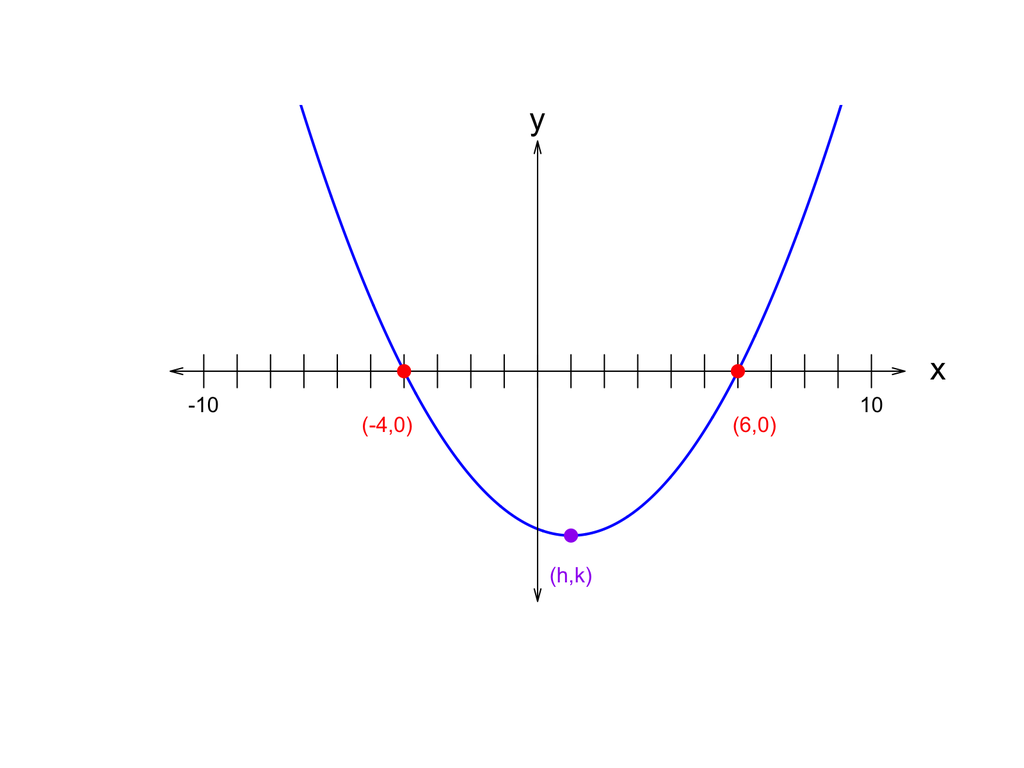

### Factored form

The polynomial $f(x)$ can be expressed in **factored form**. Which option correctly expresses $f(x)$ in factored form?

1. $f(x) = (x+{4})\cdot (x-{6})$
2. $f(x) = (x+{4})\cdot (x+{6})$
3. $f(x) = (x-{4})\cdot (x-{6})$
4. $f(x) = (x-{4})\cdot (x+{6})$

### Standard (expanded) form

The polynomial $f(x)$ can be expressed in **standard form**. Which option correctly expresses $f(x)$ in standard form?

7. $f(x) = x^{2}-{2}x-{24}$
8. $f(x) = x^{2}-{10}x+{24}$
9. $f(x) = x^{2}+{2}x-{24}$
10. $f(x) = x^{2}+{10}x+{24}$

### Vertex form

The polynomial $f(x)$ can be expressed in **vertex form**:

$$f(x)~=~ (x-h)^2+k$$

where coordinates $(h,k)$ are at the vertex of the parabola (as marked on the graph). Which option correctly expresses $f(x)$ in vertex form?

16. $f(x)~=~(x-1)^2-25$
17. $f(x)~=~(x-5)^2-1$
18. $f(x)~=~(x+1)^2-25$
19. $f(x)~=~(x+5)^2-1$

If the zeros are at $(p,0)$ and $(q,0)$, then the factored form will be: $f(x)~=~(x-p)\cdot(x-q)$. In our case, $p=-4$ and $q=6$, so in factored form:

$$f(x) = (x+{4})\cdot (x-{6})$$

To get the standard (expanded) form, we can multiply the two linear binomials (using the [FOIL method](https://en.wikipedia.org/wiki/FOIL_method) or box method).

| * | $x$ | $4$ |
| --- | --- | --- |
| $x$ | $x^2$ | ${4}x$ |
| $-6$ | ${-6}x$ | $-24$ |

$$f(x)~=~x^{2}-{6}x+{4}x-{24}$$

Combine like terms.

$$f(x)~=~x^{2}-{2}x-{24}$$

To get the vertex form, first average $p$ and $q$ to get $h$.

$$h~=~ \frac{{-4}+{6}}{2} ~=~
1$$

Then, plug $x=1$ into the factored form or the standard form to get $k$.

$$k~=~({1}+{4})\cdot({1}-{6}) ~=~
-25$$
$$k~=~(1)^2+(-2)(1)+(-24) ~=~
-25$$

So,

$$f(x)~=~(x-1)^2-25$$

A quadratic polynomial, $f(x)$, is generated by randomly selecting two parameters, $B$ and $C$, in the equation below.

$$f(x)~=~x^2+Bx+C$$

Notice the leading coefficient (of the quadratic term) is 1. However the linear coefficient and the constant are randomly determined.

When $y=f(x)$ is graphed below, you notice it has zeros (roots, $x$-intercepts) at coordinates $(2,0)$ and $(8,0)$.

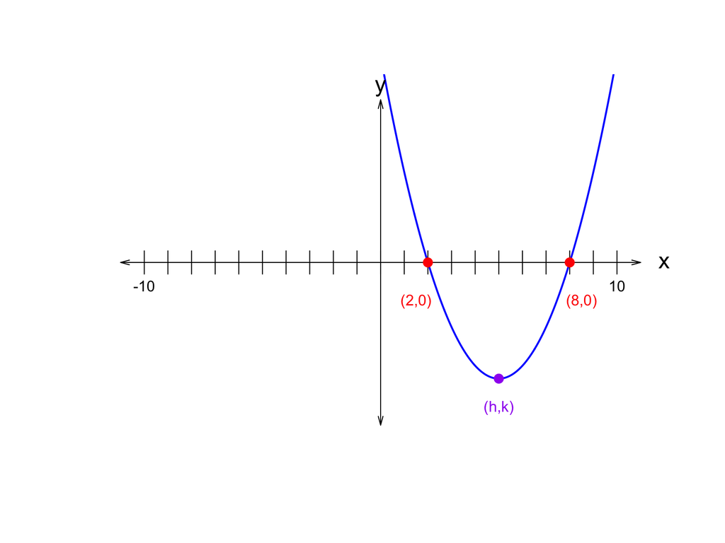

### Factored form

The polynomial $f(x)$ can be expressed in **factored form**. Which option correctly expresses $f(x)$ in factored form?

1. $f(x) = (x+{2})\cdot (x+{8})$
2. $f(x) = (x-{2})\cdot (x+{8})$
3. $f(x) = (x+{2})\cdot (x-{8})$
4. $f(x) = (x-{2})\cdot (x-{8})$

### Standard (expanded) form

The polynomial $f(x)$ can be expressed in **standard form**. Which option correctly expresses $f(x)$ in standard form?

7. $f(x) = x^{2}-{10}x+{16}$
8. $f(x) = x^{2}+{6}x-{16}$
9. $f(x) = x^{2}+{10}x+{16}$
10. $f(x) = x^{2}-{6}x-{16}$

### Vertex form

The polynomial $f(x)$ can be expressed in **vertex form**:

$$f(x)~=~ (x-h)^2+k$$

where coordinates $(h,k)$ are at the vertex of the parabola (as marked on the graph). Which option correctly expresses $f(x)$ in vertex form?

16. $f(x)~=~(x-3)^2-25$
17. $f(x)~=~(x+3)^2-25$
18. $f(x)~=~(x-5)^2-9$
19. $f(x)~=~(x+5)^2-9$

If the zeros are at $(p,0)$ and $(q,0)$, then the factored form will be: $f(x)~=~(x-p)\cdot(x-q)$. In our case, $p=2$ and $q=8$, so in factored form:

$$f(x) = (x-{2})\cdot (x-{8})$$

To get the standard (expanded) form, we can multiply the two linear binomials (using the [FOIL method](https://en.wikipedia.org/wiki/FOIL_method) or box method).

| * | $x$ | $-2$ |
| --- | --- | --- |
| $x$ | $x^2$ | ${-2}x$ |
| $-8$ | ${-8}x$ | $16$ |

$$f(x)~=~x^{2}-{8}x-{2}x+{16}$$

Combine like terms.

$$f(x)~=~x^{2}-{10}x+{16}$$

To get the vertex form, first average $p$ and $q$ to get $h$.

$$h~=~ \frac{{2}+{8}}{2} ~=~
5$$

Then, plug $x=5$ into the factored form or the standard form to get $k$.

$$k~=~({5}-{2})\cdot({5}-{8}) ~=~
-9$$
$$k~=~(5)^2+(-10)(5)+(16) ~=~
-9$$

So,

$$f(x)~=~(x-5)^2-9$$

A quadratic polynomial, $f(x)$, is generated by randomly selecting two parameters, $B$ and $C$, in the equation below.

$$f(x)~=~x^2+Bx+C$$

Notice the leading coefficient (of the quadratic term) is 1. However the linear coefficient and the constant are randomly determined.

When $y=f(x)$ is graphed below, you notice it has zeros (roots, $x$-intercepts) at coordinates $(-2,0)$ and $(8,0)$.

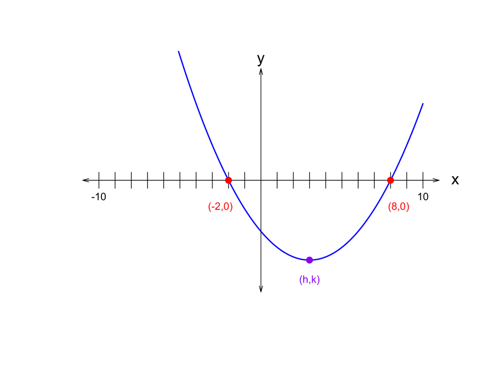

### Factored form

The polynomial $f(x)$ can be expressed in **factored form**. Which option correctly expresses $f(x)$ in factored form?

1. $f(x) = (x-{2})\cdot (x-{8})$
2. $f(x) = (x+{2})\cdot (x+{8})$
3. $f(x) = (x-{2})\cdot (x+{8})$
4. $f(x) = (x+{2})\cdot (x-{8})$

### Standard (expanded) form

The polynomial $f(x)$ can be expressed in **standard form**. Which option correctly expresses $f(x)$ in standard form?

7. $f(x) = x^{2}-{6}x-{16}$
8. $f(x) = x^{2}+{10}x+{16}$
9. $f(x) = x^{2}+{6}x-{16}$
10. $f(x) = x^{2}-{10}x+{16}$

### Vertex form

The polynomial $f(x)$ can be expressed in **vertex form**:

$$f(x)~=~ (x-h)^2+k$$

where coordinates $(h,k)$ are at the vertex of the parabola (as marked on the graph). Which option correctly expresses $f(x)$ in vertex form?

16. $f(x)~=~(x-3)^2-25$
17. $f(x)~=~(x+3)^2-25$
18. $f(x)~=~(x+5)^2-9$
19. $f(x)~=~(x-5)^2-9$

If the zeros are at $(p,0)$ and $(q,0)$, then the factored form will be: $f(x)~=~(x-p)\cdot(x-q)$. In our case, $p=-2$ and $q=8$, so in factored form:

$$f(x) = (x+{2})\cdot (x-{8})$$

To get the standard (expanded) form, we can multiply the two linear binomials (using the [FOIL method](https://en.wikipedia.org/wiki/FOIL_method) or box method).

| * | $x$ | $2$ |
| --- | --- | --- |
| $x$ | $x^2$ | ${2}x$ |
| $-8$ | ${-8}x$ | $-16$ |

$$f(x)~=~x^{2}-{8}x+{2}x-{16}$$

Combine like terms.

$$f(x)~=~x^{2}-{6}x-{16}$$

To get the vertex form, first average $p$ and $q$ to get $h$.

$$h~=~ \frac{{-2}+{8}}{2} ~=~
3$$

Then, plug $x=3$ into the factored form or the standard form to get $k$.

$$k~=~({3}+{2})\cdot({3}-{8}) ~=~
-25$$
$$k~=~(3)^2+(-6)(3)+(-16) ~=~
-25$$

So,

$$f(x)~=~(x-3)^2-25$$

A quadratic polynomial, $f(x)$, is generated by randomly selecting two parameters, $B$ and $C$, in the equation below.

$$f(x)~=~x^2+Bx+C$$

Notice the leading coefficient (of the quadratic term) is 1. However the linear coefficient and the constant are randomly determined.

When $y=f(x)$ is graphed below, you notice it has zeros (roots, $x$-intercepts) at coordinates $(-7,0)$ and $(9,0)$.

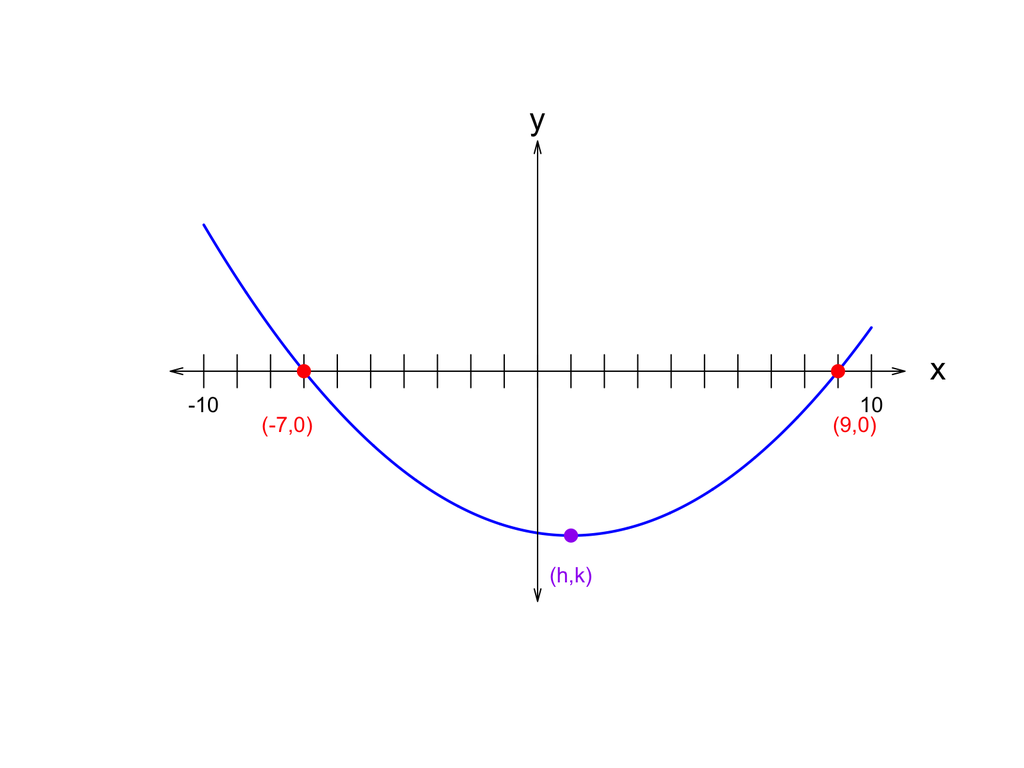

### Factored form

The polynomial $f(x)$ can be expressed in **factored form**. Which option correctly expresses $f(x)$ in factored form?

1. $f(x) = (x+{7})\cdot (x+{9})$
2. $f(x) = (x-{7})\cdot (x-{9})$
3. $f(x) = (x+{7})\cdot (x-{9})$
4. $f(x) = (x-{7})\cdot (x+{9})$

### Standard (expanded) form

The polynomial $f(x)$ can be expressed in **standard form**. Which option correctly expresses $f(x)$ in standard form?

7. $f(x) = x^{2}+{16}x+{63}$
8. $f(x) = x^{2}-{2}x-{63}$
9. $f(x) = x^{2}+{2}x-{63}$
10. $f(x) = x^{2}-{16}x+{63}$

### Vertex form

The polynomial $f(x)$ can be expressed in **vertex form**:

$$f(x)~=~ (x-h)^2+k$$

where coordinates $(h,k)$ are at the vertex of the parabola (as marked on the graph). Which option correctly expresses $f(x)$ in vertex form?

16. $f(x)~=~(x-8)^2-1$
17. $f(x)~=~(x+8)^2-1$
18. $f(x)~=~(x-1)^2-64$
19. $f(x)~=~(x+1)^2-64$

If the zeros are at $(p,0)$ and $(q,0)$, then the factored form will be: $f(x)~=~(x-p)\cdot(x-q)$. In our case, $p=-7$ and $q=9$, so in factored form:

$$f(x) = (x+{7})\cdot (x-{9})$$

To get the standard (expanded) form, we can multiply the two linear binomials (using the [FOIL method](https://en.wikipedia.org/wiki/FOIL_method) or box method).

| * | $x$ | $7$ |
| --- | --- | --- |
| $x$ | $x^2$ | ${7}x$ |
| $-9$ | ${-9}x$ | $-63$ |

$$f(x)~=~x^{2}-{9}x+{7}x-{63}$$

Combine like terms.

$$f(x)~=~x^{2}-{2}x-{63}$$

To get the vertex form, first average $p$ and $q$ to get $h$.

$$h~=~ \frac{{-7}+{9}}{2} ~=~
1$$

Then, plug $x=1$ into the factored form or the standard form to get $k$.

$$k~=~({1}+{7})\cdot({1}-{9}) ~=~
-64$$
$$k~=~(1)^2+(-2)(1)+(-63) ~=~
-64$$

So,

$$f(x)~=~(x-1)^2-64$$

A quadratic polynomial, $f(x)$, is generated by randomly selecting two parameters, $B$ and $C$, in the equation below.

$$f(x)~=~x^2+Bx+C$$

Notice the leading coefficient (of the quadratic term) is 1. However the linear coefficient and the constant are randomly determined.

When $y=f(x)$ is graphed below, you notice it has zeros (roots, $x$-intercepts) at coordinates $(-7,0)$ and $(9,0)$.

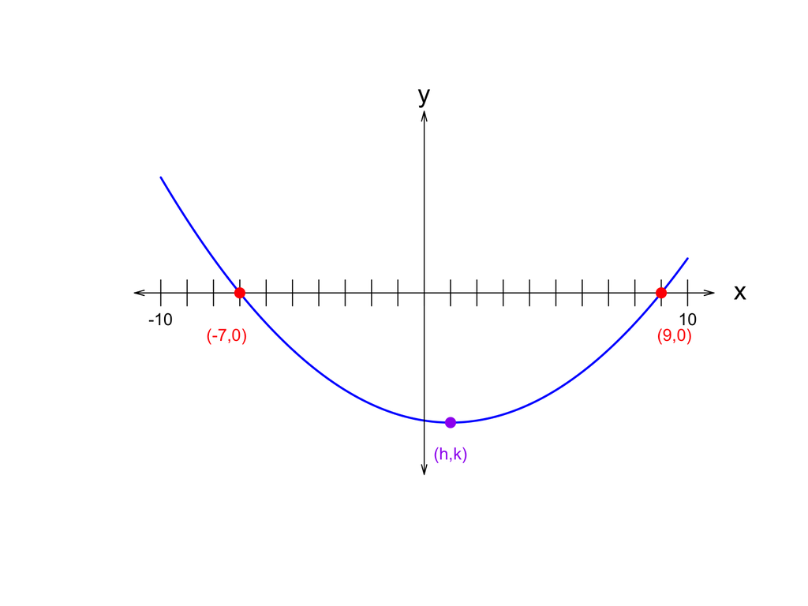

### Factored form

The polynomial $f(x)$ can be expressed in **factored form**. Which option correctly expresses $f(x)$ in factored form?

1. $f(x) = (x-{7})\cdot (x-{9})$
2. $f(x) = (x+{7})\cdot (x+{9})$
3. $f(x) = (x-{7})\cdot (x+{9})$
4. $f(x) = (x+{7})\cdot (x-{9})$

### Standard (expanded) form

The polynomial $f(x)$ can be expressed in **standard form**. Which option correctly expresses $f(x)$ in standard form?

7. $f(x) = x^{2}+{2}x-{63}$
8. $f(x) = x^{2}-{16}x+{63}$
9. $f(x) = x^{2}-{2}x-{63}$
10. $f(x) = x^{2}+{16}x+{63}$

### Vertex form

The polynomial $f(x)$ can be expressed in **vertex form**:

$$f(x)~=~ (x-h)^2+k$$

where coordinates $(h,k)$ are at the vertex of the parabola (as marked on the graph). Which option correctly expresses $f(x)$ in vertex form?

16. $f(x)~=~(x-1)^2-64$
17. $f(x)~=~(x+1)^2-64$
18. $f(x)~=~(x+8)^2-1$
19. $f(x)~=~(x-8)^2-1$

If the zeros are at $(p,0)$ and $(q,0)$, then the factored form will be: $f(x)~=~(x-p)\cdot(x-q)$. In our case, $p=-7$ and $q=9$, so in factored form:

$$f(x) = (x+{7})\cdot (x-{9})$$

To get the standard (expanded) form, we can multiply the two linear binomials (using the [FOIL method](https://en.wikipedia.org/wiki/FOIL_method) or box method).

| * | $x$ | $7$ |
| --- | --- | --- |
| $x$ | $x^2$ | ${7}x$ |
| $-9$ | ${-9}x$ | $-63$ |

$$f(x)~=~x^{2}-{9}x+{7}x-{63}$$

Combine like terms.

$$f(x)~=~x^{2}-{2}x-{63}$$

To get the vertex form, first average $p$ and $q$ to get $h$.

$$h~=~ \frac{{-7}+{9}}{2} ~=~
1$$

Then, plug $x=1$ into the factored form or the standard form to get $k$.

$$k~=~({1}+{7})\cdot({1}-{9}) ~=~
-64$$
$$k~=~(1)^2+(-2)(1)+(-63) ~=~
-64$$

So,

$$f(x)~=~(x-1)^2-64$$

A quadratic polynomial, $f(x)$, is generated by randomly selecting two parameters, $B$ and $C$, in the equation below.

$$f(x)~=~x^2+Bx+C$$

Notice the leading coefficient (of the quadratic term) is 1. However the linear coefficient and the constant are randomly determined.

When $y=f(x)$ is graphed below, you notice it has zeros (roots, $x$-intercepts) at coordinates $(-5,0)$ and $(-1,0)$.

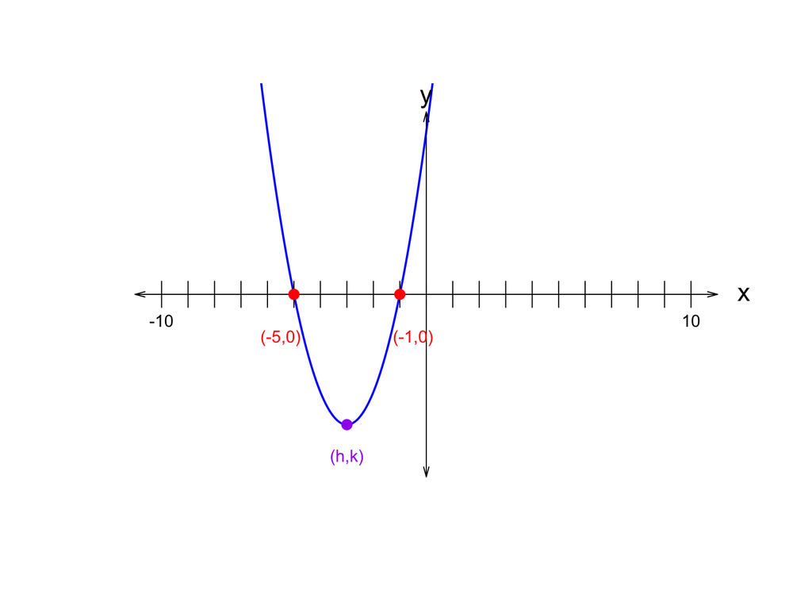

### Factored form

The polynomial $f(x)$ can be expressed in **factored form**. Which option correctly expresses $f(x)$ in factored form?

1. $f(x) = (x+{5})\cdot (x-{1})$
2. $f(x) = (x-{5})\cdot (x+{1})$
3. $f(x) = (x+{5})\cdot (x+{1})$
4. $f(x) = (x-{5})\cdot (x-{1})$

### Standard (expanded) form

The polynomial $f(x)$ can be expressed in **standard form**. Which option correctly expresses $f(x)$ in standard form?

7. $f(x) = x^{2}-{6}x+{5}$
8. $f(x) = x^{2}+{6}x+{5}$
9. $f(x) = x^{2}+{4}x-{5}$
10. $f(x) = x^{2}-{4}x-{5}$

### Vertex form

The polynomial $f(x)$ can be expressed in **vertex form**:

$$f(x)~=~ (x-h)^2+k$$

where coordinates $(h,k)$ are at the vertex of the parabola (as marked on the graph). Which option correctly expresses $f(x)$ in vertex form?

16. $f(x)~=~(x-2)^2-9$
17. $f(x)~=~(x-3)^2-4$
18. $f(x)~=~(x+3)^2-4$
19. $f(x)~=~(x+2)^2-9$

If the zeros are at $(p,0)$ and $(q,0)$, then the factored form will be: $f(x)~=~(x-p)\cdot(x-q)$. In our case, $p=-5$ and $q=-1$, so in factored form:

$$f(x) = (x+{5})\cdot (x+{1})$$

To get the standard (expanded) form, we can multiply the two linear binomials (using the [FOIL method](https://en.wikipedia.org/wiki/FOIL_method) or box method).

| * | $x$ | $5$ |
| --- | --- | --- |
| $x$ | $x^2$ | ${5}x$ |
| $1$ | $x$ | $5$ |

$$f(x)~=~x^{2}+x+{5}x+{5}$$

Combine like terms.

$$f(x)~=~x^{2}+{6}x+{5}$$

To get the vertex form, first average $p$ and $q$ to get $h$.

$$h~=~ \frac{{-5}-{1}}{2} ~=~
-3$$

Then, plug $x=-3$ into the factored form or the standard form to get $k$.

$$k~=~({-3}+{5})\cdot({-3}+{1}) ~=~
-4$$
$$k~=~(-3)^2+(6)(-3)+(5) ~=~
-4$$

So,

$$f(x)~=~(x+3)^2-4$$

A quadratic polynomial, $f(x)$, is generated by randomly selecting two parameters, $B$ and $C$, in the equation below.

$$f(x)~=~x^2+Bx+C$$

Notice the leading coefficient (of the quadratic term) is 1. However the linear coefficient and the constant are randomly determined.

When $y=f(x)$ is graphed below, you notice it has zeros (roots, $x$-intercepts) at coordinates $(-4,0)$ and $(8,0)$.

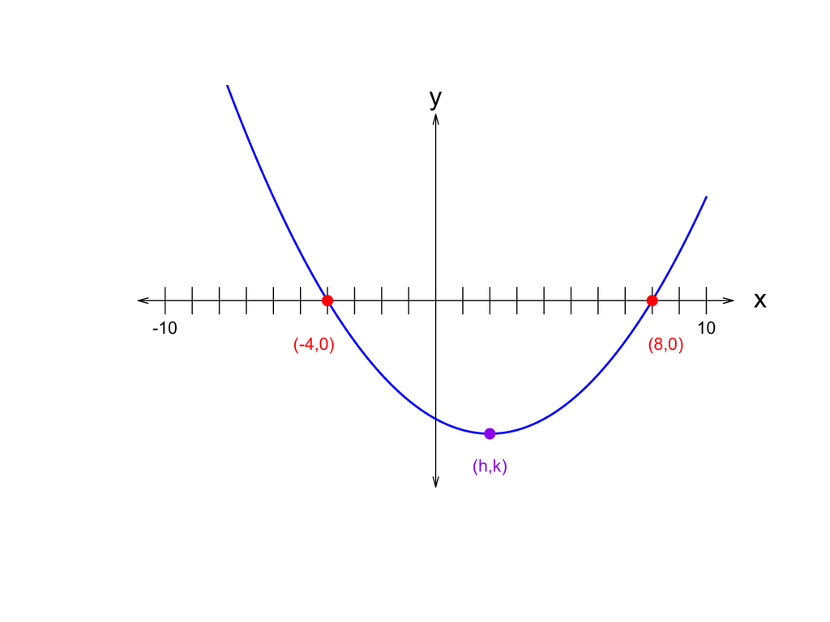

### Factored form

The polynomial $f(x)$ can be expressed in **factored form**. Which option correctly expresses $f(x)$ in factored form?

1. $f(x) = (x+{4})\cdot (x+{8})$
2. $f(x) = (x+{4})\cdot (x-{8})$
3. $f(x) = (x-{4})\cdot (x-{8})$
4. $f(x) = (x-{4})\cdot (x+{8})$

### Standard (expanded) form

The polynomial $f(x)$ can be expressed in **standard form**. Which option correctly expresses $f(x)$ in standard form?

7. $f(x) = x^{2}+{4}x-{32}$
8. $f(x) = x^{2}-{4}x-{32}$
9. $f(x) = x^{2}+{12}x+{32}$
10. $f(x) = x^{2}-{12}x+{32}$

### Vertex form

The polynomial $f(x)$ can be expressed in **vertex form**:

$$f(x)~=~ (x-h)^2+k$$

where coordinates $(h,k)$ are at the vertex of the parabola (as marked on the graph). Which option correctly expresses $f(x)$ in vertex form?

16. $f(x)~=~(x+2)^2-36$
17. $f(x)~=~(x+6)^2-4$
18. $f(x)~=~(x-2)^2-36$
19. $f(x)~=~(x-6)^2-4$

If the zeros are at $(p,0)$ and $(q,0)$, then the factored form will be: $f(x)~=~(x-p)\cdot(x-q)$. In our case, $p=-4$ and $q=8$, so in factored form:

$$f(x) = (x+{4})\cdot (x-{8})$$

To get the standard (expanded) form, we can multiply the two linear binomials (using the [FOIL method](https://en.wikipedia.org/wiki/FOIL_method) or box method).

| * | $x$ | $4$ |
| --- | --- | --- |
| $x$ | $x^2$ | ${4}x$ |
| $-8$ | ${-8}x$ | $-32$ |

$$f(x)~=~x^{2}-{8}x+{4}x-{32}$$

Combine like terms.

$$f(x)~=~x^{2}-{4}x-{32}$$

To get the vertex form, first average $p$ and $q$ to get $h$.

$$h~=~ \frac{{-4}+{8}}{2} ~=~
2$$

Then, plug $x=2$ into the factored form or the standard form to get $k$.

$$k~=~({2}+{4})\cdot({2}-{8}) ~=~
-36$$
$$k~=~(2)^2+(-4)(2)+(-32) ~=~
-36$$

So,

$$f(x)~=~(x-2)^2-36$$

A polynomial is sketched below.

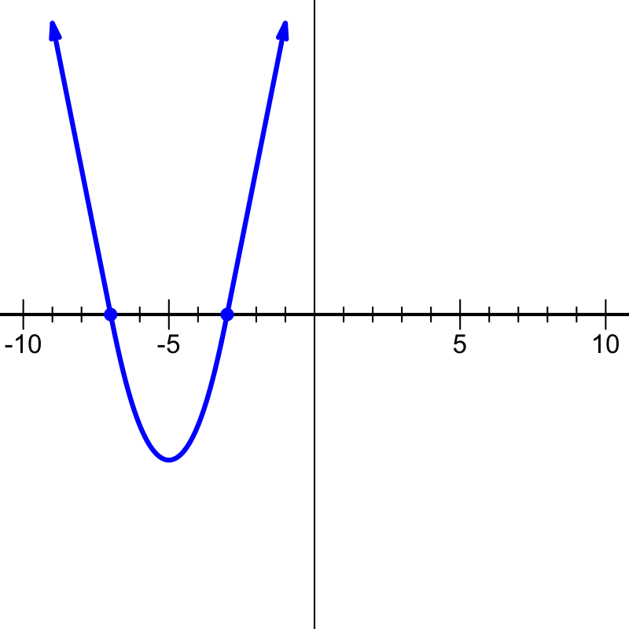

Which polynomial (in factored form) best matches the sketch?

$y=-(x+3)(x+7)$$y=-(x-3)(x-7)$$y=(x-3)(x-7)$$y=(x+3)(x+7)$

If a polynomial has a factor of $(x-r)$, then there will be an $x$-intercept at $(r,0)$.

In this case, the roots (the $x$-intercepts) are at:

$$-7,\,-3$$

Thus, the factors are $x+7$ and $x+3$. So, we know that the function could be written as:

$$y=a(x+7)(x+3)$$

where $a$ is some constant.

Lastly, we need to determine whether $a$ should be positive or negative. In this problem, either $a=1$ or $a=-1$. To determine this, look at the right side of the graph. Specifically, we are considering the [end behavior of polynomials](https://www.khanacademy.org/math/algebra2/x2ec2f6f830c9fb89:poly-graphs/x2ec2f6f830c9fb89:poly-end-behavior/a/end-behavior-of-polynomials). Notice that once $x$ is larger than $-3$, all the factors will be positive, so only $a$ will dictate whether the function on the right side is positive or negative.

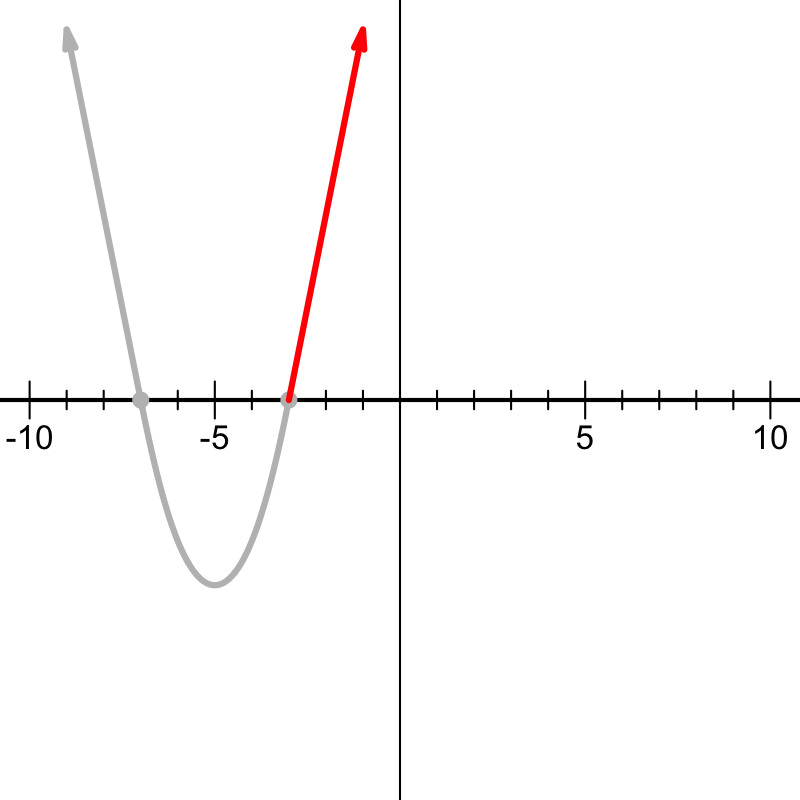

Notice, on the right side, the function is heading up. I guess more importantly, as $x\to \infty$ we see the function is positive. This implies that $a$ is positive. So, in this case, $a=1$.

$$y=(x+7)(x+3)$$

And then, since multiplication is commutative, the factors can be written in any order. In this case, the correct answer is:

$$y=(x+3)(x+7)$$

A polynomial is sketched below.

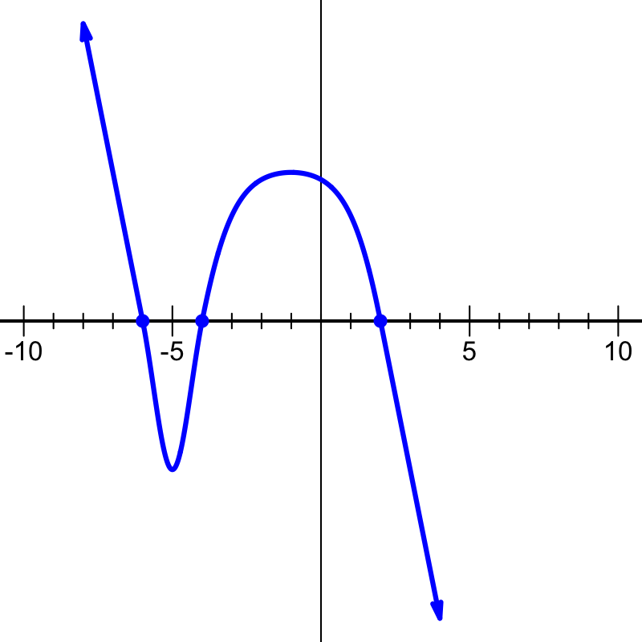

Which polynomial (in factored form) best matches the sketch?

$y=-(x+6)(x+4)(x-2)$$y=-(x-6)(x-4)(x+2)$$y=(x+6)(x+4)(x-2)$$y=(x-6)(x-4)(x+2)$

If a polynomial has a factor of $(x-r)$, then there will be an $x$-intercept at $(r,0)$.

In this case, the roots (the $x$-intercepts) are at:

$$-6,\,-4,\,2$$

Thus, the factors are $x+6$ and $x+4$ and $x-2$. So, we know that the function could be written as:

$$y=a(x+6)(x+4)(x-2)$$

where $a$ is some constant.

Lastly, we need to determine whether $a$ should be positive or negative. In this problem, either $a=1$ or $a=-1$. To determine this, look at the right side of the graph. Specifically, we are considering the [end behavior of polynomials](https://www.khanacademy.org/math/algebra2/x2ec2f6f830c9fb89:poly-graphs/x2ec2f6f830c9fb89:poly-end-behavior/a/end-behavior-of-polynomials). Notice that once $x$ is larger than $2$, all the factors will be positive, so only $a$ will dictate whether the function on the right side is positive or negative.

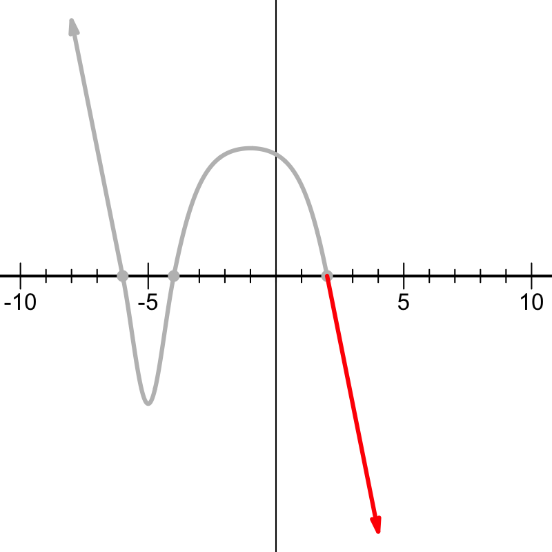

Notice, on the right side, the function is heading down. I guess more importantly, as $x\to \infty$ we see the function is negative. This implies that $a$ is negative. So, in this case, $a=-1$.

$$y=-(x+6)(x+4)(x-2)$$

A polynomial is sketched below.

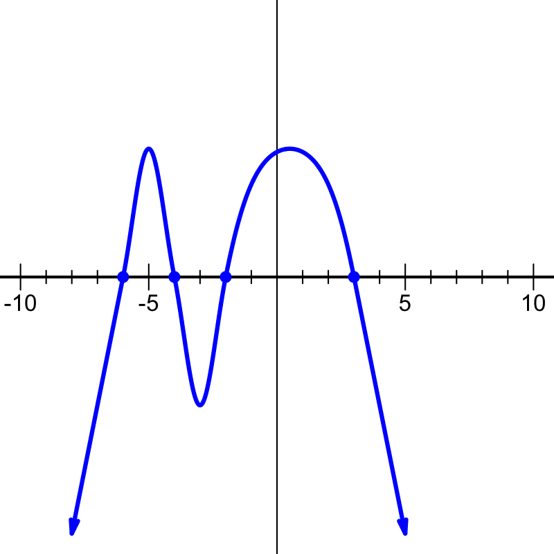

Which polynomial (in factored form) best matches the sketch?

$y=(x+4)(x-3)(x+2)(x+6)$$y=(x-4)(x+3)(x-2)(x-6)$$y=-(x+4)(x-3)(x+2)(x+6)$$y=-(x-4)(x+3)(x-2)(x-6)$

If a polynomial has a factor of $(x-r)$, then there will be an $x$-intercept at $(r,0)$.

In this case, the roots (the $x$-intercepts) are at:

$$-6,\,-4,\,-2,\,3$$

Thus, the factors are $x+6$ and $x+4$ and $x+2$ and $x-3$. So, we know that the function could be written as:

$$y=a(x+6)(x+4)(x+2)(x-3)$$

where $a$ is some constant.

Lastly, we need to determine whether $a$ should be positive or negative. In this problem, either $a=1$ or $a=-1$. To determine this, look at the right side of the graph. Specifically, we are considering the [end behavior of polynomials](https://www.khanacademy.org/math/algebra2/x2ec2f6f830c9fb89:poly-graphs/x2ec2f6f830c9fb89:poly-end-behavior/a/end-behavior-of-polynomials). Notice that once $x$ is larger than $3$, all the factors will be positive, so only $a$ will dictate whether the function on the right side is positive or negative.

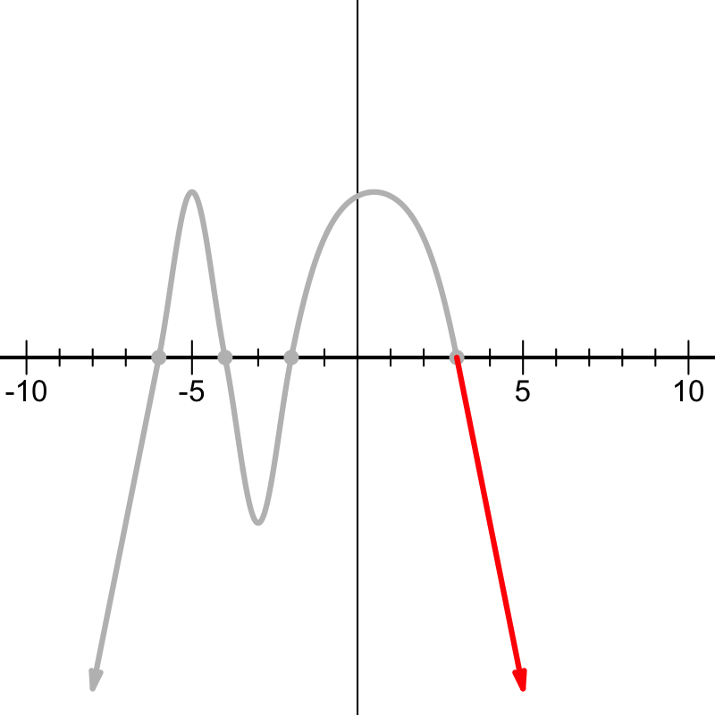

Notice, on the right side, the function is heading down. I guess more importantly, as $x\to \infty$ we see the function is negative. This implies that $a$ is negative. So, in this case, $a=-1$.

$$y=-(x+6)(x+4)(x+2)(x-3)$$

And then, since multiplication is commutative, the factors can be written in any order. In this case, the correct answer is:

$$y=-(x+4)(x-3)(x+2)(x+6)$$

A polynomial is sketched below.

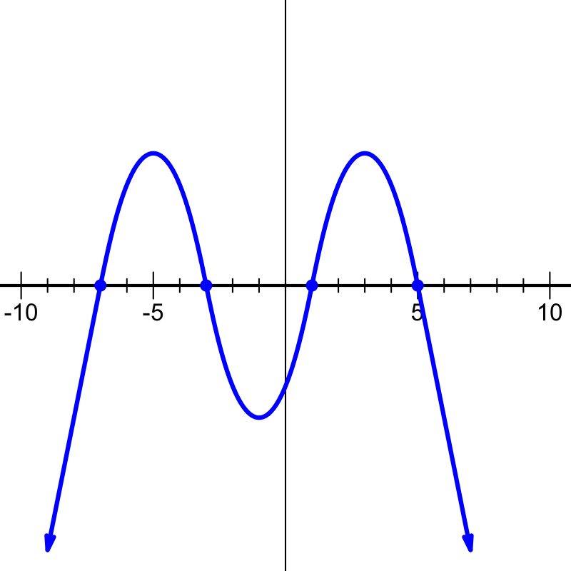

Which polynomial (in factored form) best matches the sketch?

$y=-(x+3)(x-1)(x-5)(x+7)$$y=(x+3)(x-1)(x-5)(x+7)$$y=(x-3)(x+1)(x+5)(x-7)$$y=-(x-3)(x+1)(x+5)(x-7)$

If a polynomial has a factor of $(x-r)$, then there will be an $x$-intercept at $(r,0)$.

In this case, the roots (the $x$-intercepts) are at:

$$-7,\,-3,\,1,\,5$$

Thus, the factors are $x+7$ and $x+3$ and $x-1$ and $x-5$. So, we know that the function could be written as:

$$y=a(x+7)(x+3)(x-1)(x-5)$$

where $a$ is some constant.

Lastly, we need to determine whether $a$ should be positive or negative. In this problem, either $a=1$ or $a=-1$. To determine this, look at the right side of the graph. Specifically, we are considering the [end behavior of polynomials](https://www.khanacademy.org/math/algebra2/x2ec2f6f830c9fb89:poly-graphs/x2ec2f6f830c9fb89:poly-end-behavior/a/end-behavior-of-polynomials). Notice that once $x$ is larger than $5$, all the factors will be positive, so only $a$ will dictate whether the function on the right side is positive or negative.

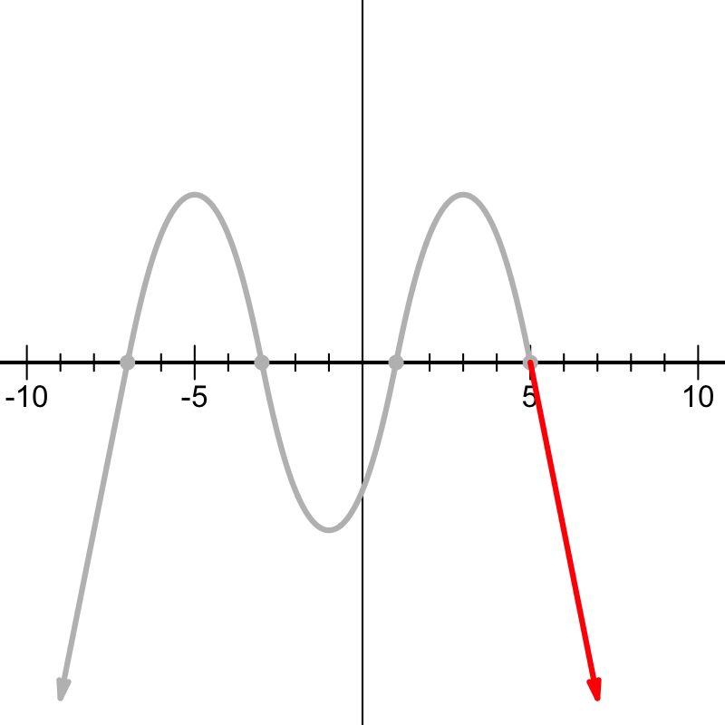

Notice, on the right side, the function is heading down. I guess more importantly, as $x\to \infty$ we see the function is negative. This implies that $a$ is negative. So, in this case, $a=-1$.

$$y=-(x+7)(x+3)(x-1)(x-5)$$

And then, since multiplication is commutative, the factors can be written in any order. In this case, the correct answer is:

$$y=-(x+3)(x-1)(x-5)(x+7)$$

A polynomial is sketched below.

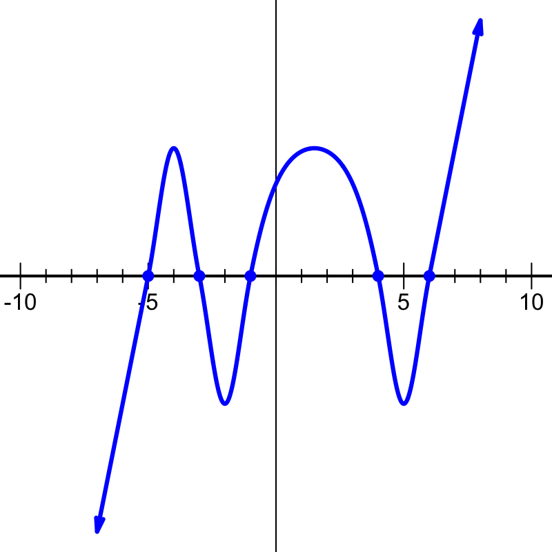

Which polynomial (in factored form) best matches the sketch?

$y=-(x+3)(x+1)(x-6)(x-4)(x+5)$$y=(x-3)(x-1)(x+6)(x+4)(x-5)$$y=-(x-3)(x-1)(x+6)(x+4)(x-5)$$y=(x+3)(x+1)(x-6)(x-4)(x+5)$

If a polynomial has a factor of $(x-r)$, then there will be an $x$-intercept at $(r,0)$.

In this case, the roots (the $x$-intercepts) are at:

$$-5,\,-3,\,-1,\,4,\,6$$

Thus, the factors are $x+5$ and $x+3$ and $x+1$ and $x-4$ and $x-6$. So, we know that the function could be written as:

$$y=a(x+5)(x+3)(x+1)(x-4)(x-6)$$

where $a$ is some constant.

Lastly, we need to determine whether $a$ should be positive or negative. In this problem, either $a=1$ or $a=-1$. To determine this, look at the right side of the graph. Specifically, we are considering the [end behavior of polynomials](https://www.khanacademy.org/math/algebra2/x2ec2f6f830c9fb89:poly-graphs/x2ec2f6f830c9fb89:poly-end-behavior/a/end-behavior-of-polynomials). Notice that once $x$ is larger than $6$, all the factors will be positive, so only $a$ will dictate whether the function on the right side is positive or negative.

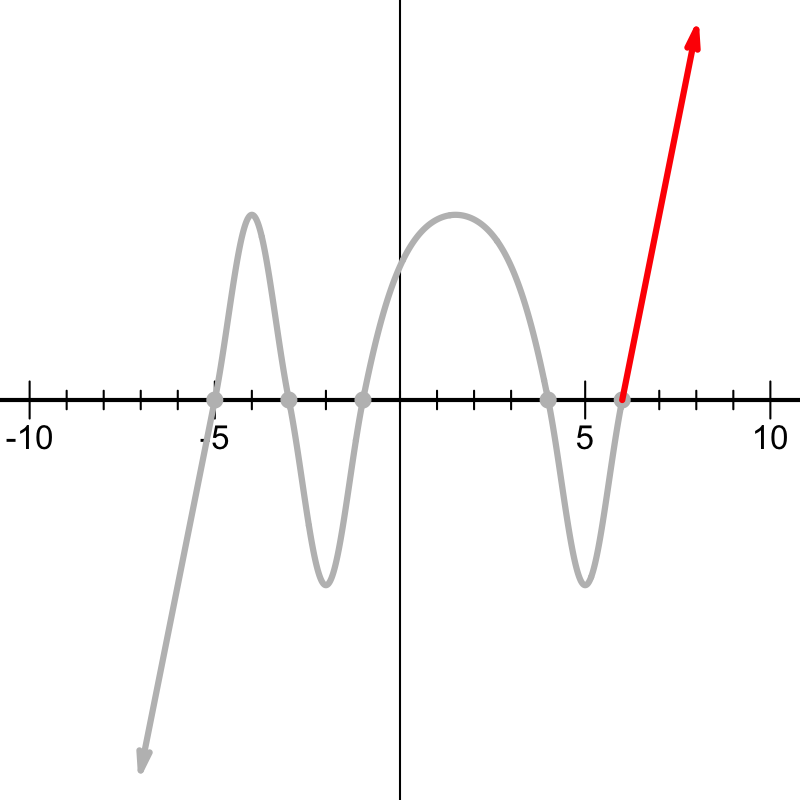

Notice, on the right side, the function is heading up. I guess more importantly, as $x\to \infty$ we see the function is positive. This implies that $a$ is positive. So, in this case, $a=1$.

$$y=(x+5)(x+3)(x+1)(x-4)(x-6)$$

And then, since multiplication is commutative, the factors can be written in any order. In this case, the correct answer is:

$$y=(x+3)(x+1)(x-6)(x-4)(x+5)$$

A polynomial is sketched below.

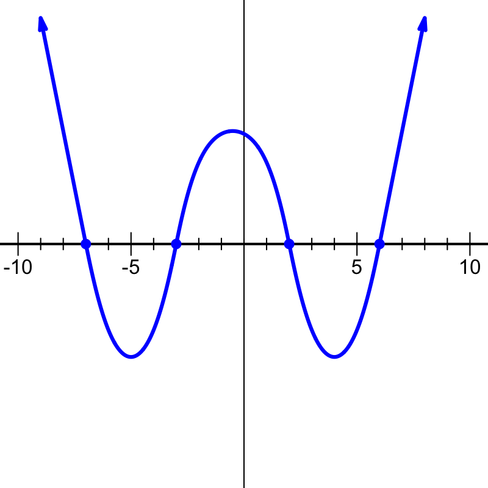

Which polynomial (in factored form) best matches the sketch?

$y=(x-2)(x-6)(x+7)(x+3)$$y=-(x+2)(x+6)(x-7)(x-3)$$y=-(x-2)(x-6)(x+7)(x+3)$$y=(x+2)(x+6)(x-7)(x-3)$

If a polynomial has a factor of $(x-r)$, then there will be an $x$-intercept at $(r,0)$.

In this case, the roots (the $x$-intercepts) are at:

$$-7,\,-3,\,2,\,6$$

Thus, the factors are $x+7$ and $x+3$ and $x-2$ and $x-6$. So, we know that the function could be written as:

$$y=a(x+7)(x+3)(x-2)(x-6)$$

where $a$ is some constant.

Lastly, we need to determine whether $a$ should be positive or negative. In this problem, either $a=1$ or $a=-1$. To determine this, look at the right side of the graph. Specifically, we are considering the [end behavior of polynomials](https://www.khanacademy.org/math/algebra2/x2ec2f6f830c9fb89:poly-graphs/x2ec2f6f830c9fb89:poly-end-behavior/a/end-behavior-of-polynomials). Notice that once $x$ is larger than $6$, all the factors will be positive, so only $a$ will dictate whether the function on the right side is positive or negative.

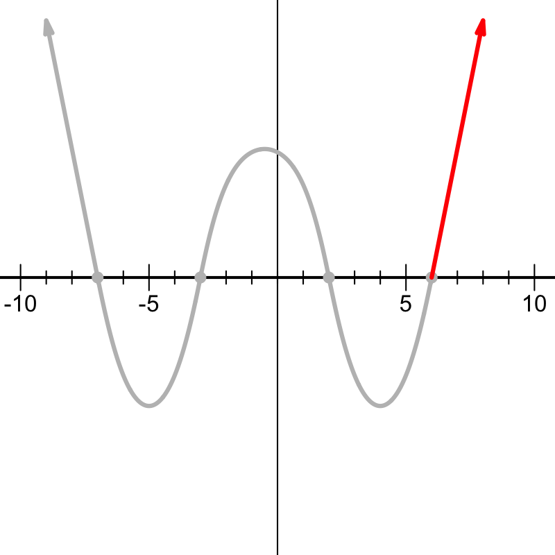

Notice, on the right side, the function is heading up. I guess more importantly, as $x\to \infty$ we see the function is positive. This implies that $a$ is positive. So, in this case, $a=1$.

$$y=(x+7)(x+3)(x-2)(x-6)$$

And then, since multiplication is commutative, the factors can be written in any order. In this case, the correct answer is:

$$y=(x-2)(x-6)(x+7)(x+3)$$

A polynomial is sketched below.

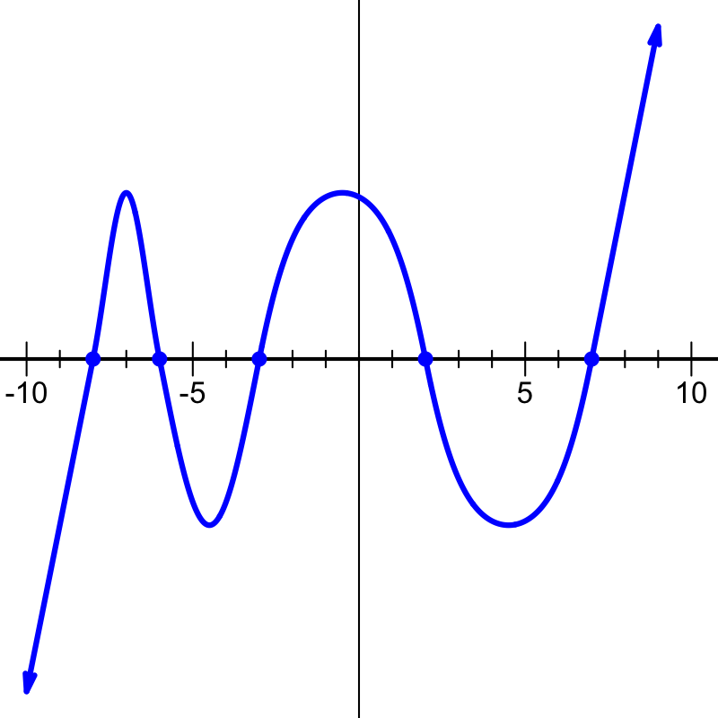

Which polynomial (in factored form) best matches the sketch?

$y=(x-6)(x-3)(x-8)(x+2)(x+7)$$y=(x+6)(x+3)(x+8)(x-2)(x-7)$$y=-(x-6)(x-3)(x-8)(x+2)(x+7)$$y=-(x+6)(x+3)(x+8)(x-2)(x-7)$

If a polynomial has a factor of $(x-r)$, then there will be an $x$-intercept at $(r,0)$.

In this case, the roots (the $x$-intercepts) are at:

$$-8,\,-6,\,-3,\,2,\,7$$

Thus, the factors are $x+8$ and $x+6$ and $x+3$ and $x-2$ and $x-7$. So, we know that the function could be written as:

$$y=a(x+8)(x+6)(x+3)(x-2)(x-7)$$

where $a$ is some constant.

Lastly, we need to determine whether $a$ should be positive or negative. In this problem, either $a=1$ or $a=-1$. To determine this, look at the right side of the graph. Specifically, we are considering the [end behavior of polynomials](https://www.khanacademy.org/math/algebra2/x2ec2f6f830c9fb89:poly-graphs/x2ec2f6f830c9fb89:poly-end-behavior/a/end-behavior-of-polynomials). Notice that once $x$ is larger than $7$, all the factors will be positive, so only $a$ will dictate whether the function on the right side is positive or negative.

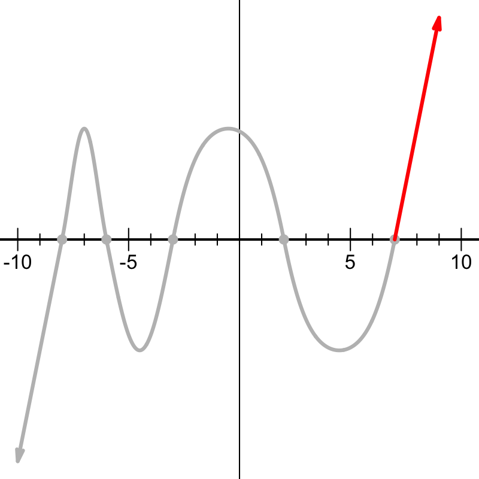

Notice, on the right side, the function is heading up. I guess more importantly, as $x\to \infty$ we see the function is positive. This implies that $a$ is positive. So, in this case, $a=1$.

$$y=(x+8)(x+6)(x+3)(x-2)(x-7)$$

And then, since multiplication is commutative, the factors can be written in any order. In this case, the correct answer is:

$$y=(x+6)(x+3)(x+8)(x-2)(x-7)$$

A polynomial is sketched below.

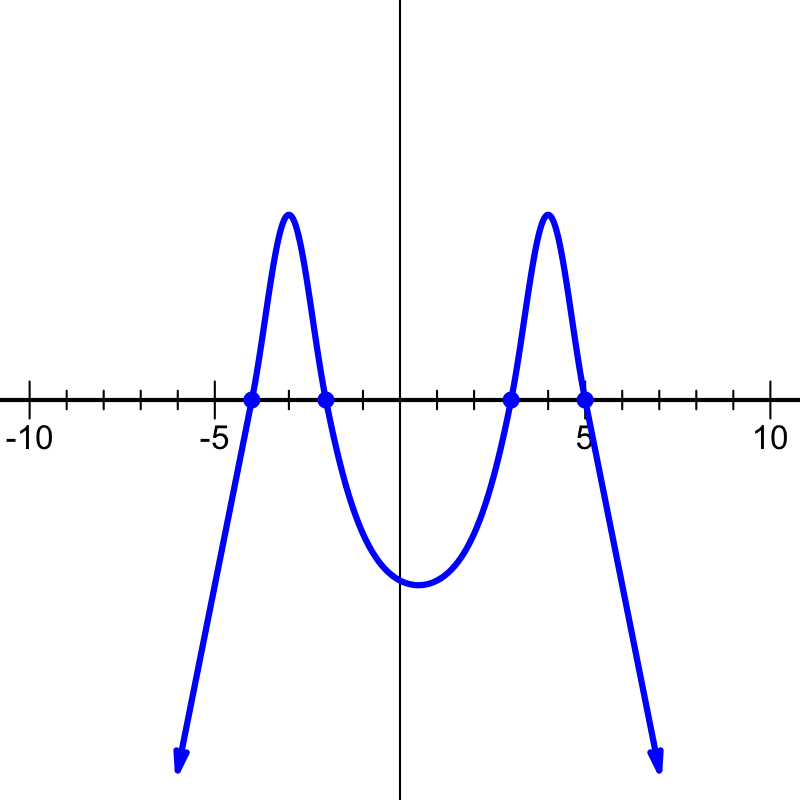

Which polynomial (in factored form) best matches the sketch?

$y=-(x-4)(x+3)(x-2)(x+5)$$y=(x+4)(x-3)(x+2)(x-5)$$y=(x-4)(x+3)(x-2)(x+5)$$y=-(x+4)(x-3)(x+2)(x-5)$

If a polynomial has a factor of $(x-r)$, then there will be an $x$-intercept at $(r,0)$.

In this case, the roots (the $x$-intercepts) are at:

$$-4,\,-2,\,3,\,5$$

Thus, the factors are $x+4$ and $x+2$ and $x-3$ and $x-5$. So, we know that the function could be written as:

$$y=a(x+4)(x+2)(x-3)(x-5)$$

where $a$ is some constant.

Lastly, we need to determine whether $a$ should be positive or negative. In this problem, either $a=1$ or $a=-1$. To determine this, look at the right side of the graph. Specifically, we are considering the [end behavior of polynomials](https://www.khanacademy.org/math/algebra2/x2ec2f6f830c9fb89:poly-graphs/x2ec2f6f830c9fb89:poly-end-behavior/a/end-behavior-of-polynomials). Notice that once $x$ is larger than $5$, all the factors will be positive, so only $a$ will dictate whether the function on the right side is positive or negative.

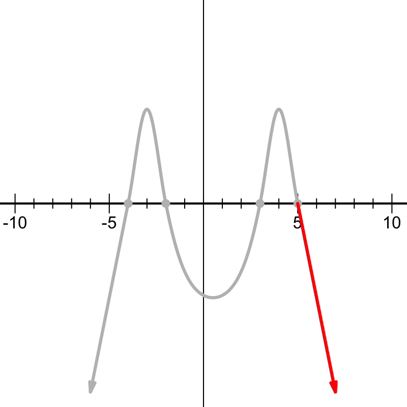

Notice, on the right side, the function is heading down. I guess more importantly, as $x\to \infty$ we see the function is negative. This implies that $a$ is negative. So, in this case, $a=-1$.

$$y=-(x+4)(x+2)(x-3)(x-5)$$

And then, since multiplication is commutative, the factors can be written in any order. In this case, the correct answer is:

$$y=-(x+4)(x-3)(x+2)(x-5)$$

A polynomial is sketched below.

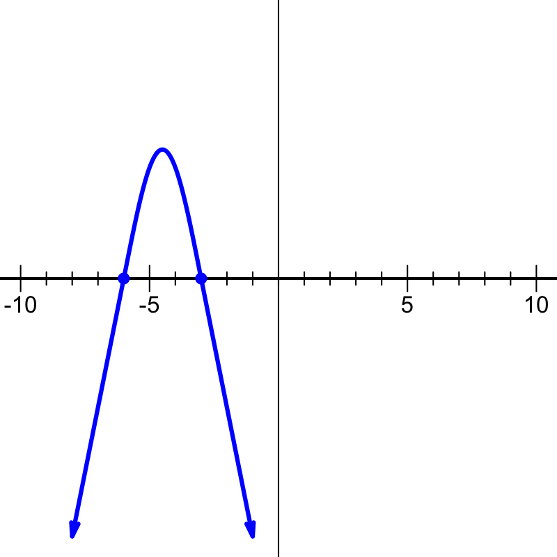

Which polynomial (in factored form) best matches the sketch?

$y=(x+6)(x+3)$$y=-(x+6)(x+3)$$y=(x-6)(x-3)$$y=-(x-6)(x-3)$

If a polynomial has a factor of $(x-r)$, then there will be an $x$-intercept at $(r,0)$.

In this case, the roots (the $x$-intercepts) are at:

$$-6,\,-3$$

Thus, the factors are $x+6$ and $x+3$. So, we know that the function could be written as:

$$y=a(x+6)(x+3)$$

where $a$ is some constant.

Lastly, we need to determine whether $a$ should be positive or negative. In this problem, either $a=1$ or $a=-1$. To determine this, look at the right side of the graph. Specifically, we are considering the [end behavior of polynomials](https://www.khanacademy.org/math/algebra2/x2ec2f6f830c9fb89:poly-graphs/x2ec2f6f830c9fb89:poly-end-behavior/a/end-behavior-of-polynomials). Notice that once $x$ is larger than $-3$, all the factors will be positive, so only $a$ will dictate whether the function on the right side is positive or negative.

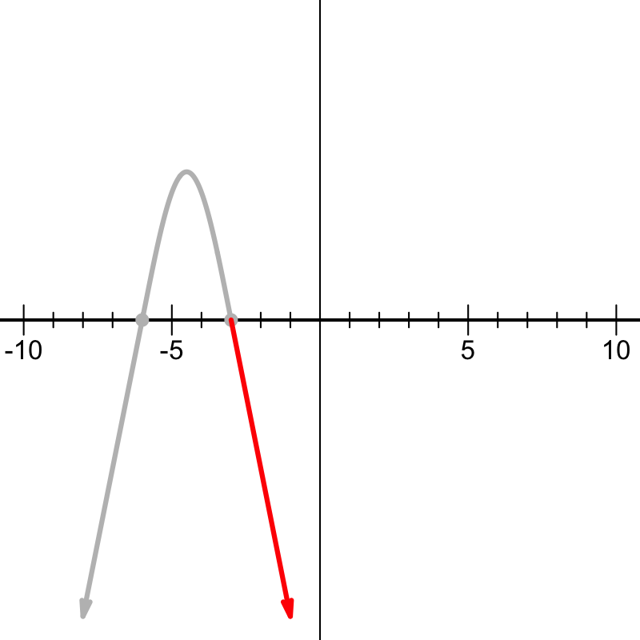

Notice, on the right side, the function is heading down. I guess more importantly, as $x\to \infty$ we see the function is negative. This implies that $a$ is negative. So, in this case, $a=-1$.